# Análisis exploratorio

**Test 2 Prueba Data Science Capgemini**

**Javier Crespo Guerrero** (javicrespi2000@gmail.com)

En este notebook realizaremos el análisis exploratorio y comprobaciones de estacionalidad de la serie temporal escogida.

## El Dataset Escogido

El dataset escogido es [Electricity Transformer Dataset](https://github.com/zhouhaoyi/ETDataset), donde tendremos que predecir la temperatura del aceite dentro del transformador a partir de una serie de indicadores de carga, con datos correspondientes a dos años recogidos cada hora. En este caso utilizaremos la versión del dataset accesible a través de la libería *darts* como [ETTh1Dataset](https://unit8co.github.io/darts/generated_api/darts.datasets.html#darts.datasets.ETTm1Dataset). Las variables son las siguientes, según la descripción de la fuente:

- `date`: The recorded date
- `HUFL`: High UseFul Load
- `HULL`: High UseLess Load
- `MUFL`: Medium UseFul Load
- `MULL`: Medium UseLess Load
- `LUFL`: Low UseFul Load
- `LULL`: Low UseLess Load
- `OT`: Oil Temperature (Target)

### *¿Por qué este Dataset?*

He escogido este Dataset porque presenta un problema de regresión de una serie temporal multivariante, pero con un tamaño asequible para este ejercicio.

### La estacionalidad

Uno de los requisitos del ejercicio era que la variable objetivo fuese no estacional. Para ello, vamos a utilizar métodos de desestacionalización sobre la serie original y a partir de la serie desestacionalizada construiremos el modelo de regresión.

```python
# Lectura y procesado de datos
import pandas as pd

# Visualizacion
import matplotlib.pyplot as plt

# Tratamiento y visualizacion de Series Temporales
from darts.utils.statistics import plot_acf, check_seasonality, remove_seasonality, plot_ccf
from darts.utils.utils import SeasonalityMode

# Dataset
from darts.datasets import ETTh1Dataset

# Parametros necesarios
RANDOM_SEED = 2024

TARGET = 'OT'

PAST_COVARIATES = ['HUFL', 'HULL', 'MUFL', 'MULL', 'LUFL', 'LULL']
```

## Lectura y visualización básica

```python
# Lectura de los datos
series = ETTh1Dataset().load()
```

```
Tenemos 17420 datos
DatetimeIndex(['2016-07-01 00:00:00', '2016-07-01 01:00:00',
               '2016-07-01 02:00:00', '2016-07-01 03:00:00',
               '2016-07-01 04:00:00'],
              dtype='datetime64[ns]', name='date', freq='h')
DatetimeIndex(['2018-06-26 15:00:00', '2018-06-26 16:00:00',
               '2018-06-26 17:00:00', '2018-06-26 18:00:00',
               '2018-06-26 19:00:00'],
              dtype='datetime64[ns]', name='date', freq='h')
```

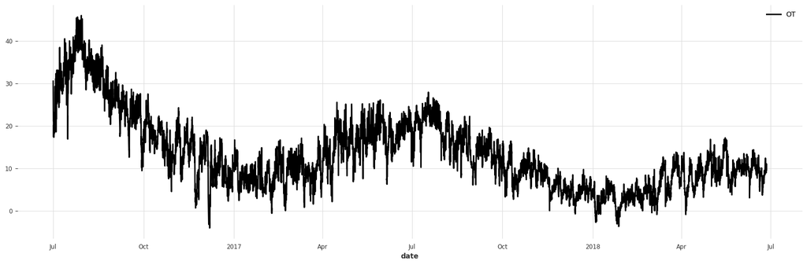

```python
print(f'Tenemos {len(series)} datos')
print(series.time_index[:5])
print(series.time_index[-5:])

plt.figure(figsize=(20, 6))
series[TARGET].plot()
plt.show()
```

Tenemos 17420 puntos de datos. **Por razones computacionales vamos a utilizar solamente los datos correspondientes a los últimos 3 meses para ajustar los modelos**, puesto que se van a ejecutar algoritmos y métodos costosos que sobrepasan la capacidad de esta máquina.

Por supuesto, en un entorno real habría que usar el dataset completo y buscar formas de mejorar el rendimiento mediante, por ejemplo, aceleración por GPU.

```python
_, series = series.split_after(pd.Timestamp('2018-04-01 00:00:00'))
len(series)
```

```
2083
```

Ahora disponemos de 2083 puntos de datos correspondientes al año 2018.

### La variable objetivo

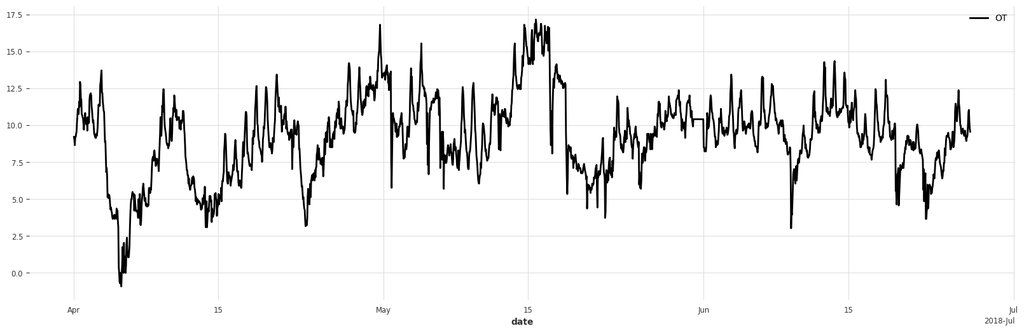

```python
plt.figure(figsize=(20, 6))
series[TARGET].plot()
```

Parece que estamos ante una serie con tendencia ligeramente creciente, varianza aparentemente constante y sin outliers apartenes. Vamos a estudiar el resto de regresores que utilizaremos.

### Las covariables

A continuación vamos a pasar a estudiar las covariables. Hay dos grupos: los que hablan de "Useful Load" *(HUFL, MUFL y LULF)* y sobre "UseLess Load" *(HULL, MULL, LULL)*, vamos a representar cada uno de estos dos grupos juntos.

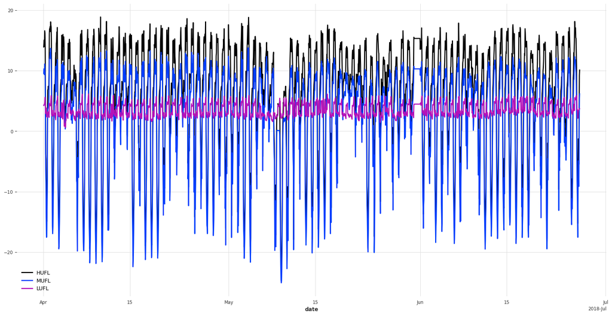

```python
plt.figure(figsize=(20, 10))
series[['HUFL', 'MUFL', 'LUFL']].plot()
```

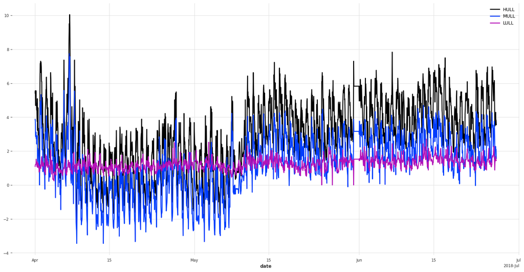

```python
plt.figure(figsize=(20, 10))
series[['HULL', 'MULL', 'LULL']].plot()
```

Las variables parecen recoger cierta variedad y tendencias, lo que a priori es útil para predecir la serie objetivo. Sin embargo, parece que algunas series tienen una forma muy similar entre sí, lo que podría afectar al modelo final. Vamos a representar cada covariable por separado para poder visualizar mejor la forma.

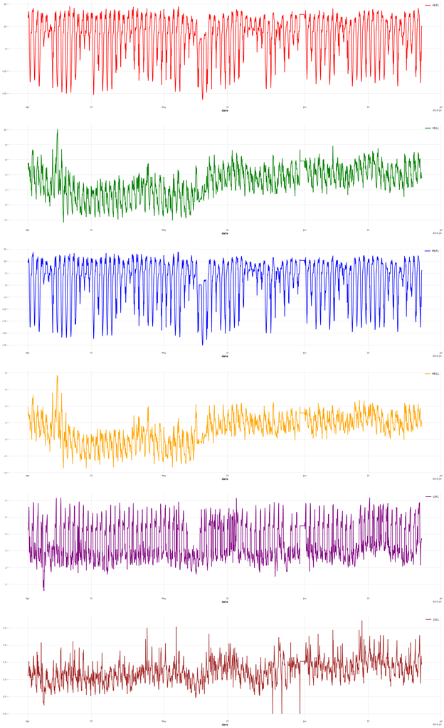

```python
fig, axs = plt.subplots(len(PAST_COVARIATES), 1)
fig.set_figheight(50)
fig.set_figwidth(30)

colors = ['red', 'green', 'blue', 'orange', 'purple', 'brown']
for var, axis, color in zip(PAST_COVARIATES, axs, colors):
    series[var].plot(new_plot = False, ax=axis, color=color)
```

Efectivamente, hay parejas de variables con formas bastante similares (por ejemplo, *HUFL* y *MUFL*), por lo que tendremos que ser cuidadosos a la hora de establecer los parámetros de regularización de los modelos que vayamos a escoger.

### Correlación entre variable objetivo y covariables

```
Variable - HUFL
```

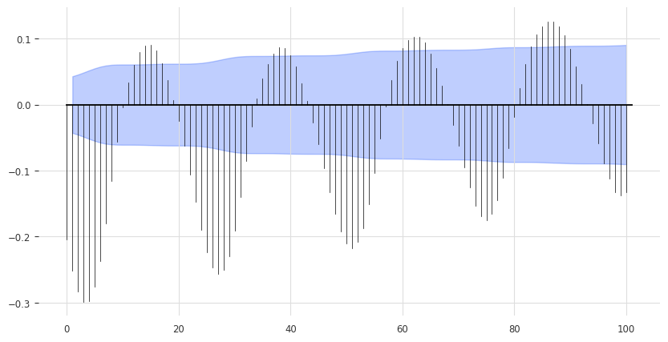

```
Variable - HULL
```

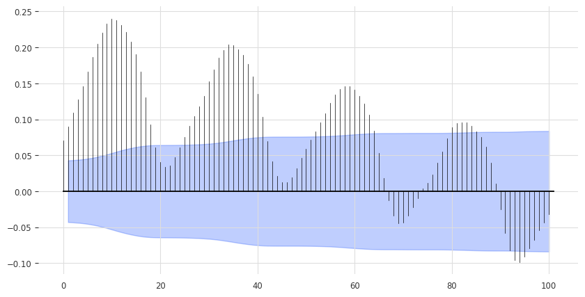

```
Variable - MUFL
```

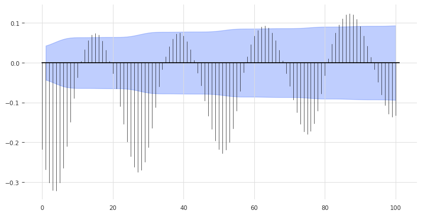

```
Variable - MULL
```

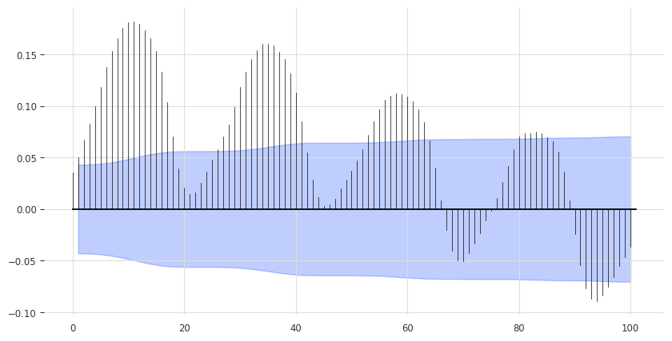

```
Variable - LUFL
```

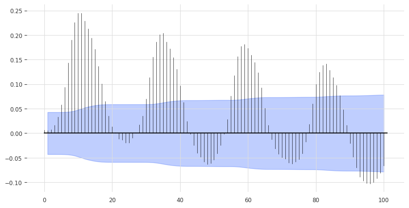

```
Variable - LULL
```

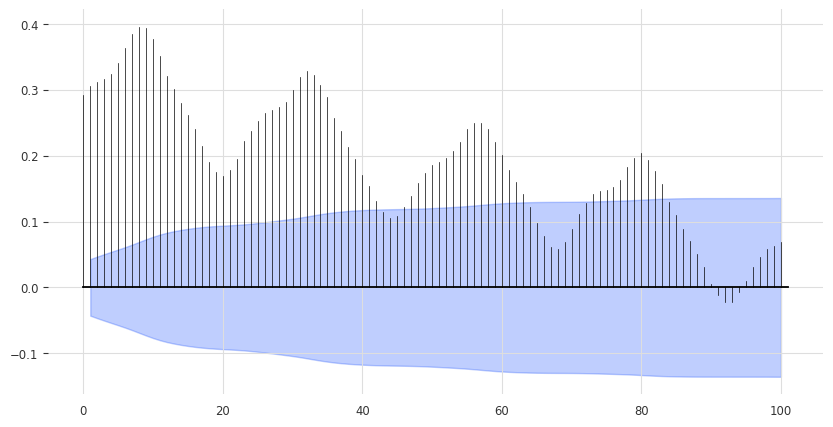

```python
for var in PAST_COVARIATES:
    print(f'Variable - {var}')
    plot_ccf(series[TARGET], series[var], max_lag=100)
    plt.show()
```

Sin entrar al detalle de cada variable, vemos que las covariables parecen estar correladas con distintos aspectos de la serie objetivo, lo que a priori es un buen indicador de poder predictivo.

## Estacionalidad de la serie

A continuación vamos a comprobar la estacionalida de la serie objetivo comprobando su correlograma.

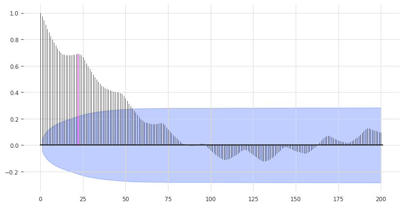

```python
plot_acf(series[TARGET], max_lag=200, m=22)
```

Claramente la autocorrelación en el retardo 22 destaca y es indicativa de estacionalidad.

Vamos a utilizar el test que incluye la librería *darts* utilizando la fórmula de Barlett. En este caso el test nos devolverá el primer retardo en el que la serie es estacional, por lo que podría haber más periodos.

```python
is_seasonal, period = check_seasonality(series[TARGET], alpha=0.05, max_lag=200)
if is_seasonal:
    print('There is seasonality of order {}.'.format(period))
```

```
There is seasonality of order 22.
```

Hay estacionalidad, al menos de orden 22. Como en el ejercicio se nos pide trabajar con una serie desestacionalizada vamos a desestacionalizar la serie asumiendo una estacionalidad aditiva, puesto que vimos en el plot que la varianza no parecía aumentar con el tiempo.

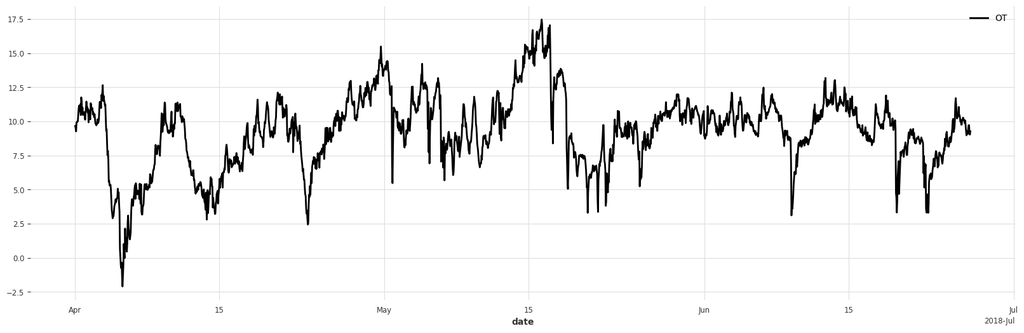

```python
unseasonal_series = remove_seasonality(series[TARGET], model=SeasonalityMode.ADDITIVE)
series = series[PAST_COVARIATES].stack(unseasonal_series)

plt.figure(figsize=(20, 6))
series[TARGET].plot()
```

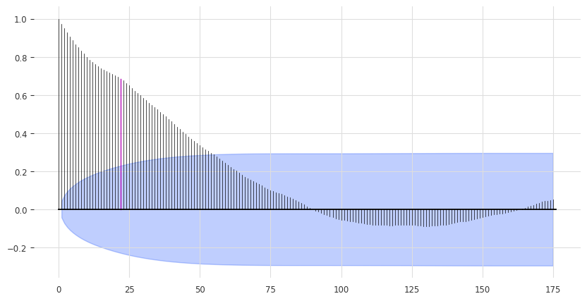

```python
plot_acf(series[TARGET], max_lag=175, m=22)
```

```python
is_seasonal, period = check_seasonality(series[TARGET], alpha=0.05, max_lag=175)
if is_seasonal:
    print('There is seasonality of order {}.'.format(period))
```

Podemos considerar esta nueva serie como no estacional, por lo que vamos a construir el modelo a partir de ella en el siguiente notebook.

```python
# Guardamos los datos con la nueva serie desestacionalizada
series.to_csv('electricity_transformer.csv')
```